# Practical ML Final Project

Jeffrey Richardson

April 2018

- A - Exactly according to the specification
- B - Throwing elbows to the front
- C - Lifting the dumbbell only halfway
- D - Lowering the dumbbell only halfway
- E - Throwing hips to the front

Class A corresponds to correct execution

Classes B through E are types of mistakes

This is a supervised learning problem concerning multiclass classification

# Data Preparation

## Read in data

```r
# Load packages without warning messages,  https://stackoverflow.com/questions/18931006/how-to-suppress-warning-messages-when-loading-a-library
suppressWarnings(suppressMessages(library(caret)))
suppressWarnings(suppressMessages(library(dplyr)))
suppressWarnings(suppressMessages(library(kernlab)))
suppressWarnings(suppressMessages(library(ggplot2)))
suppressWarnings(suppressMessages(library(lubridate)))
suppressWarnings(suppressMessages(library(tidyr)))
suppressWarnings(suppressMessages(library(corrplot)))
suppressWarnings(suppressMessages(library(viridis)))
suppressWarnings(suppressMessages(library(knitr)))
suppressWarnings(suppressMessages(library(scales)))
suppressWarnings(suppressMessages(library(stringr)))
suppressWarnings(suppressMessages(library(ggrepel)))
suppressWarnings(suppressMessages(library(pander)))


# Directory where data is located
dir <- "/Users/jeffreyrichardson/Documents/Coursera/"

# Training dataset
pml_trn <- read.table(paste(dir, "pml-training.csv", sep = ""), as.is = TRUE, sep = ",", header = TRUE)

# Several variables, user names, time-stamps, dates, etc.won't be useful for predictions.

# Remove non-relevant variables, change remaining character class to numerics, re-combine with 'classe'
suppressWarnings( # Remove warnings notifying that columns will have NA values when converted to numeric
     trn <- read.table(paste(dir, "pml-training.csv",
                             sep = ""), as.is = TRUE, sep = ",", header = TRUE) %>%
          select(-c(X,user_name,raw_timestamp_part_1,raw_timestamp_part_2,
                    cvtd_timestamp,new_window,classe)) %>%
          mutate_if(is.character, funs(as.numeric)) %>%
          bind_cols(select(pml_trn,classe))
)

# Read in the testing data
pml_tst <- read.table(paste(dir, "pml-testing.csv", sep = ""), as.is = TRUE, sep = ",", header = TRUE)

# Remove non-relevant variables, change remaining logical class to numerics, re-combine with 'problem_id'
tst <- read.table(paste(dir, "pml-testing.csv", sep = ""),
                  as.is = TRUE, sep = ",", header = TRUE) %>%
     select(-c(X,user_name,raw_timestamp_part_1,raw_timestamp_part_2,
               cvtd_timestamp,new_window,problem_id)) %>%
     mutate_if(is.logical, funs(as.numeric)) %>%
     bind_cols(select(pml_tst, problem_id))

# Clear
rm(pml_tst,pml_trn)
```

## Inspect & Explore data

Create a function to count the number of na values & percentage of na values for each variable. Check for na’s

```r
#
naf <- function(x) {
     library(scales); z <- x
     tot <- sum(is.na(z)); pct <- percent(tot / length(z))
     paste(tot, pct, sep = ", ")}

# Check for columns with entirely na values in test set
sapply(tst[, ], naf)
```

```
##               num_window                roll_belt               pitch_belt
##                  "0, 0%"                  "0, 0%"                  "0, 0%"
##                 yaw_belt         total_accel_belt       kurtosis_roll_belt
##                  "0, 0%"                  "0, 0%"               "20, 100%"
##      kurtosis_picth_belt        kurtosis_yaw_belt       skewness_roll_belt
##               "20, 100%"               "20, 100%"               "20, 100%"
##     skewness_roll_belt.1        skewness_yaw_belt            max_roll_belt
##               "20, 100%"               "20, 100%"               "20, 100%"
##           max_picth_belt             max_yaw_belt            min_roll_belt
##               "20, 100%"               "20, 100%"               "20, 100%"
##           min_pitch_belt             min_yaw_belt      amplitude_roll_belt
##               "20, 100%"               "20, 100%"               "20, 100%"
##     amplitude_pitch_belt       amplitude_yaw_belt     var_total_accel_belt
##               "20, 100%"               "20, 100%"               "20, 100%"
##            avg_roll_belt         stddev_roll_belt            var_roll_belt
##               "20, 100%"               "20, 100%"               "20, 100%"
##           avg_pitch_belt        stddev_pitch_belt           var_pitch_belt
##               "20, 100%"               "20, 100%"               "20, 100%"
##             avg_yaw_belt          stddev_yaw_belt             var_yaw_belt
##               "20, 100%"               "20, 100%"               "20, 100%"
##             gyros_belt_x             gyros_belt_y             gyros_belt_z
##                  "0, 0%"                  "0, 0%"                  "0, 0%"
##             accel_belt_x             accel_belt_y             accel_belt_z
##                  "0, 0%"                  "0, 0%"                  "0, 0%"
##            magnet_belt_x            magnet_belt_y            magnet_belt_z
##                  "0, 0%"                  "0, 0%"                  "0, 0%"
##                 roll_arm                pitch_arm                  yaw_arm
##                  "0, 0%"                  "0, 0%"                  "0, 0%"
##          total_accel_arm            var_accel_arm             avg_roll_arm
##                  "0, 0%"               "20, 100%"               "20, 100%"
##          stddev_roll_arm             var_roll_arm            avg_pitch_arm
##               "20, 100%"               "20, 100%"               "20, 100%"
##         stddev_pitch_arm            var_pitch_arm              avg_yaw_arm
##               "20, 100%"               "20, 100%"               "20, 100%"
##           stddev_yaw_arm              var_yaw_arm              gyros_arm_x
##               "20, 100%"               "20, 100%"                  "0, 0%"
##              gyros_arm_y              gyros_arm_z              accel_arm_x
##                  "0, 0%"                  "0, 0%"                  "0, 0%"
##              accel_arm_y              accel_arm_z             magnet_arm_x
##                  "0, 0%"                  "0, 0%"                  "0, 0%"
```

[output cut: 49 more lines]

```
##               "20, 100%"                  "0, 0%"               "20, 100%"
##         avg_roll_forearm      stddev_roll_forearm         var_roll_forearm
##               "20, 100%"               "20, 100%"               "20, 100%"
##        avg_pitch_forearm     stddev_pitch_forearm        var_pitch_forearm
##               "20, 100%"               "20, 100%"               "20, 100%"
##          avg_yaw_forearm       stddev_yaw_forearm          var_yaw_forearm
##               "20, 100%"               "20, 100%"               "20, 100%"
##          gyros_forearm_x          gyros_forearm_y          gyros_forearm_z
##                  "0, 0%"                  "0, 0%"                  "0, 0%"
##          accel_forearm_x          accel_forearm_y          accel_forearm_z
##                  "0, 0%"                  "0, 0%"                  "0, 0%"
##         magnet_forearm_x         magnet_forearm_y         magnet_forearm_z
##                  "0, 0%"                  "0, 0%"                  "0, 0%"
##               problem_id
##                  "0, 0%"
```

Before going any further, it will probably be helpful to learn a little about the data itself first

```r
names(trn)
```

```
##   [1] "num_window"               "roll_belt"
##   [3] "pitch_belt"               "yaw_belt"
##   [5] "total_accel_belt"         "kurtosis_roll_belt"
##   [7] "kurtosis_picth_belt"      "kurtosis_yaw_belt"
##   [9] "skewness_roll_belt"       "skewness_roll_belt.1"
##  [11] "skewness_yaw_belt"        "max_roll_belt"
##  [13] "max_picth_belt"           "max_yaw_belt"
##  [15] "min_roll_belt"            "min_pitch_belt"
##  [17] "min_yaw_belt"             "amplitude_roll_belt"
##  [19] "amplitude_pitch_belt"     "amplitude_yaw_belt"
##  [21] "var_total_accel_belt"     "avg_roll_belt"
##  [23] "stddev_roll_belt"         "var_roll_belt"
##  [25] "avg_pitch_belt"           "stddev_pitch_belt"
##  [27] "var_pitch_belt"           "avg_yaw_belt"
##  [29] "stddev_yaw_belt"          "var_yaw_belt"
```

[output cut: 62 more lines]

The column names are completely unfamiliar to me. What in the world is yaw?

This was a good resource from howthingsfly.si.edu, [What are roll, pitch & yaw?](https://howthingsfly.si.edu/flight-dynamics/roll-pitch-and-yaw), where the following has been copied

- Imagine lines x, y, z intersecting at right angles
  - Rotation around the front-to-back axis is called roll.
  - Rotation around the side-to-side axis is called pitch.
  - Rotation around the vertical axis is called yaw.

Definitions of skewness and kurtosis were found here - https://itl.nist.gov/div898/handbook/eda/section3/eda35b.htm - and copied below

- “Skewness is a measure of symmetry, or more precisely, the lack of symmetry. A distribution, or data set, is symmetric if it looks the same to the left and right of the center point.”
- “Kurtosis is a measure of whether the data are heavy-tailed or light-tailed relative to a normal distribution. That is, data sets with high kurtosis tend to have heavy tails, or outliers. Data sets with low kurtosis tend to have light tails, or lack of outliers. A uniform distribution would be the extreme case.”

Back to the analysis…

Remove columns with all na values in test set using this [neat little trick](https://stackoverflow.com/questions/15968494/how-to-delete-columns-that-contain-only-nas/15968937)

```r
# https://stackoverflow.com/questions/15968494/how-to-delete-columns-that-contain-only-nas/15968937
tst <- tst[, colSums(is.na(tst)) != nrow(tst)]; str(tst)
```

```
## 'data.frame':    20 obs. of  54 variables:
##  $ num_window          : int  74 431 439 194 235 504 485 440 323 664 ...
##  $ roll_belt           : num  123 1.02 0.87 125 1.35 -5.92 1.2 0.43 0.93 114 ...
##  $ pitch_belt          : num  27 4.87 1.82 -41.6 3.33 1.59 4.44 4.15 6.72 22.4 ...
##  $ yaw_belt            : num  -4.75 -88.9 -88.5 162 -88.6 -87.7 -87.3 -88.5 -93.7 -13.1 ...
##  $ total_accel_belt    : int  20 4 5 17 3 4 4 4 4 18 ...
##  $ gyros_belt_x        : num  -0.5 -0.06 0.05 0.11 0.03 0.1 -0.06 -0.18 0.1 0.14 ...
##  $ gyros_belt_y        : num  -0.02 -0.02 0.02 0.11 0.02 0.05 0 -0.02 0 0.11 ...
##  $ gyros_belt_z        : num  -0.46 -0.07 0.03 -0.16 0 -0.13 0 -0.03 -0.02 -0.16 ...
##  $ accel_belt_x        : int  -38 -13 1 46 -8 -11 -14 -10 -15 -25 ...
##  $ accel_belt_y        : int  69 11 -1 45 4 -16 2 -2 1 63 ...
##  $ accel_belt_z        : int  -179 39 49 -156 27 38 35 42 32 -158 ...
##  $ magnet_belt_x       : int  -13 43 29 169 33 31 50 39 -6 10 ...
##  $ magnet_belt_y       : int  581 636 631 608 566 638 622 635 600 601 ...
##  $ magnet_belt_z       : int  -382 -309 -312 -304 -418 -291 -315 -305 -302 -330 ...
```

[output cut: 40 more lines]

Only leaves 54 columns

Remove columns from training data that don’t appear in test set.

```r
trn <- trn[, names(trn) %in% names(tst) | names(trn) == "classe"]

sapply(trn, naf)
```

```
##           num_window            roll_belt           pitch_belt
##              "0, 0%"              "0, 0%"              "0, 0%"
##             yaw_belt     total_accel_belt         gyros_belt_x
##              "0, 0%"              "0, 0%"              "0, 0%"
##         gyros_belt_y         gyros_belt_z         accel_belt_x
##              "0, 0%"              "0, 0%"              "0, 0%"
##         accel_belt_y         accel_belt_z        magnet_belt_x
##              "0, 0%"              "0, 0%"              "0, 0%"
##        magnet_belt_y        magnet_belt_z             roll_arm
##              "0, 0%"              "0, 0%"              "0, 0%"
##            pitch_arm              yaw_arm      total_accel_arm
##              "0, 0%"              "0, 0%"              "0, 0%"
##          gyros_arm_x          gyros_arm_y          gyros_arm_z
##              "0, 0%"              "0, 0%"              "0, 0%"
##          accel_arm_x          accel_arm_y          accel_arm_z
##              "0, 0%"              "0, 0%"              "0, 0%"
##         magnet_arm_x         magnet_arm_y         magnet_arm_z
##              "0, 0%"              "0, 0%"              "0, 0%"
##        roll_dumbbell       pitch_dumbbell         yaw_dumbbell
##              "0, 0%"              "0, 0%"              "0, 0%"
## total_accel_dumbbell     gyros_dumbbell_x     gyros_dumbbell_y
##              "0, 0%"              "0, 0%"              "0, 0%"
##     gyros_dumbbell_z     accel_dumbbell_x     accel_dumbbell_y
##              "0, 0%"              "0, 0%"              "0, 0%"
##     accel_dumbbell_z    magnet_dumbbell_x    magnet_dumbbell_y
##              "0, 0%"              "0, 0%"              "0, 0%"
##    magnet_dumbbell_z         roll_forearm        pitch_forearm
##              "0, 0%"              "0, 0%"              "0, 0%"
##          yaw_forearm  total_accel_forearm      gyros_forearm_x
##              "0, 0%"              "0, 0%"              "0, 0%"
##      gyros_forearm_y      gyros_forearm_z      accel_forearm_x
##              "0, 0%"              "0, 0%"              "0, 0%"
##      accel_forearm_y      accel_forearm_z     magnet_forearm_x
##              "0, 0%"              "0, 0%"              "0, 0%"
##     magnet_forearm_y     magnet_forearm_z               classe
##              "0, 0%"              "0, 0%"              "0, 0%"
```

Check for covariates with no variability

```r
nsv <- nearZeroVar(trn, saveMetrics = TRUE); nsv; rm(nsv)
```

```
##                      freqRatio percentUnique zeroVar   nzv
## num_window            1.000000     4.3726430   FALSE FALSE
## roll_belt             1.101904     6.7781062   FALSE FALSE
## pitch_belt            1.036082     9.3772296   FALSE FALSE
## yaw_belt              1.058480     9.9734991   FALSE FALSE
## total_accel_belt      1.063160     0.1477933   FALSE FALSE
## gyros_belt_x          1.058651     0.7134849   FALSE FALSE
## gyros_belt_y          1.144000     0.3516461   FALSE FALSE
## gyros_belt_z          1.066214     0.8612782   FALSE FALSE
## accel_belt_x          1.055412     0.8357966   FALSE FALSE
## accel_belt_y          1.113725     0.7287738   FALSE FALSE
## accel_belt_z          1.078767     1.5237998   FALSE FALSE
## magnet_belt_x         1.090141     1.6664968   FALSE FALSE
## magnet_belt_y         1.099688     1.5187035   FALSE FALSE
## magnet_belt_z         1.006369     2.3290184   FALSE FALSE
## roll_arm             52.338462    13.5256345   FALSE FALSE
## pitch_arm            87.256410    15.7323412   FALSE FALSE
## yaw_arm              33.029126    14.6570176   FALSE FALSE
## total_accel_arm       1.024526     0.3363572   FALSE FALSE
## gyros_arm_x           1.015504     3.2769341   FALSE FALSE
## gyros_arm_y           1.454369     1.9162165   FALSE FALSE
## gyros_arm_z           1.110687     1.2638875   FALSE FALSE
## accel_arm_x           1.017341     3.9598410   FALSE FALSE
## accel_arm_y           1.140187     2.7367241   FALSE FALSE
## accel_arm_z           1.128000     4.0362858   FALSE FALSE
## magnet_arm_x          1.000000     6.8239731   FALSE FALSE
## magnet_arm_y          1.056818     4.4439914   FALSE FALSE
## magnet_arm_z          1.036364     6.4468454   FALSE FALSE
## roll_dumbbell         1.022388    84.2065029   FALSE FALSE
## pitch_dumbbell        2.277372    81.7449801   FALSE FALSE
## yaw_dumbbell          1.132231    83.4828254   FALSE FALSE
## total_accel_dumbbell  1.072634     0.2191418   FALSE FALSE
## gyros_dumbbell_x      1.003268     1.2282132   FALSE FALSE
## gyros_dumbbell_y      1.264957     1.4167771   FALSE FALSE
## gyros_dumbbell_z      1.060100     1.0498420   FALSE FALSE
## accel_dumbbell_x      1.018018     2.1659362   FALSE FALSE
## accel_dumbbell_y      1.053061     2.3748853   FALSE FALSE
## accel_dumbbell_z      1.133333     2.0894914   FALSE FALSE
## magnet_dumbbell_x     1.098266     5.7486495   FALSE FALSE
## magnet_dumbbell_y     1.197740     4.3012945   FALSE FALSE
## magnet_dumbbell_z     1.020833     3.4451126   FALSE FALSE
## roll_forearm         11.589286    11.0895933   FALSE FALSE
## pitch_forearm        65.983051    14.8557741   FALSE FALSE
## yaw_forearm          15.322835    10.1467740   FALSE FALSE
## total_accel_forearm   1.128928     0.3567424   FALSE FALSE
## gyros_forearm_x       1.059273     1.5187035   FALSE FALSE
## gyros_forearm_y       1.036554     3.7763735   FALSE FALSE
## gyros_forearm_z       1.122917     1.5645704   FALSE FALSE
## accel_forearm_x       1.126437     4.0464784   FALSE FALSE
## accel_forearm_y       1.059406     5.1116094   FALSE FALSE
## accel_forearm_z       1.006250     2.9558659   FALSE FALSE
## magnet_forearm_x      1.012346     7.7667924   FALSE FALSE
## magnet_forearm_y      1.246914     9.5403119   FALSE FALSE
## magnet_forearm_z      1.000000     8.5771073   FALSE FALSE
## classe                1.469581     0.0254816   FALSE FALSE
```

There is sufficient variability in each column, no further variables will be removed.

## Partition data

60% training set, 20% each for testing & validation sets

```r
# Set seed
set.seed(1357)
inTrain <- createDataPartition(y = trn$classe,
                               p = 0.6,
                               list = FALSE)
x <- trn[-inTrain, ]
training <- trn[inTrain, ]

# Create validation and test sets
set.seed(1113)
inTrain <- createDataPartition(y = x$classe,
                               p = 0.5,
                               list = FALSE)

validation <- x[inTrain, ]
testing <- x[-inTrain,]

# Change 'classe' to a factor
validation$classe <- factor(validation$classe)
testing$classe <- factor(testing$classe)

# Clear
rm(trn,x,inTrain)

dim(training)
```

```
## [1] 11776    54
```

```r
dim(testing)
```

```
## [1] 3923   54
```

```r
dim(validation)
```

```
## [1] 3923   54
```

# Build Model

## Pre-processing

Use corrplot to check for correlated predictors using the technique taught by Professor Leek in one of the lectures

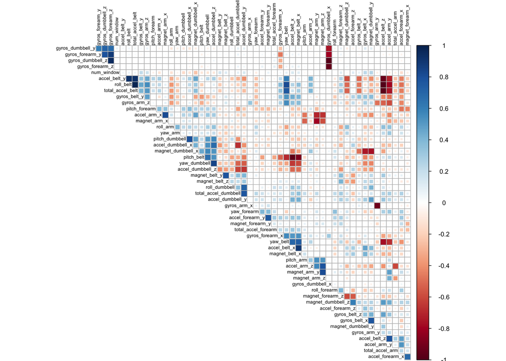

```r
cor_trn <- cor(training[, -54])
diag(cor_trn) <- 0
corrplot(cor_trn,
         diag = FALSE,
         tl.offset = 0.05,
         type = "upper",
         method = "square",
         order = "hclust",
         tl.cex = 0.6, tl.col = "black")
```

Notice above that there are several highly (negatively & positively) correlated predictors which suggests that preprocessing the data may be advantageous.

The train() function in the caret package will automatically apply any pre-processing functions to the test set with the predict() command. (Thanks Max Kuhn!)

All pre-processing for this analysis will therefore be computed within the caret train() function.

## Choose a Model

[This website](https://topepo.github.io/caret/available-models.html) - https://topepo.github.io/caret/available-models.html - was a valuable resource in experimenting with different models. Support vector machines, naive bayes, multinomial regression, neural networks, and other built-in caret models were explored.

Two methods proved to be much more accurate than the others - Random Forest (method = “rf”) as well as Bagged Classification & Regression Trees (method = “treebag”).

Each of these methods resulted in predictions with 98% accuracy and above.

As this author is quite new to machine learning, it seems important to explore the different knobs & levers avaiable inside the caret train() function. How does varying the pre-processing & training controls affect a model’s runtime & accuracy?

Create several different variations of the ‘treebag’ and ‘rf’ models. Adjust the pre-processing & train control arguments for each different model. Save each model into an .rds file to avoid having to run again

Create a new data frame to manually document the runtime for each model as they are run

```r
# Bagged classification and regression tree
# set.seed(3137)
# modStart <- Sys.time() %>% print
# bagMod <- train(classe ~ .,
#                 method = "treebag",
#                 data = training)
#
# modEnd <- Sys.time()
# modEnd - modStart # Time difference of 3.53528 mins
# saveRDS(bagMod, paste(dir, "treeBagModel.rds", sep = ""))

rt <- data.frame(Type = "Default", Method = "treebag", Runtime = 3.53528, stringsAsFactors = FALSE)

# Random Forest
# set.seed(8387)
# xStart <- Sys.time() %>% print
# rfMod <- train(classe ~ .,
#                method = "rf",
#                data = training)
#
# xEnd <- Sys.time()
# xEnd - xStart # Time difference of 41.0043 mins
# saveRDS(rfMod, paste(dir, "RandomForest_Model.rds", sep = "")) # Saved Sunday the 15th

rt <- bind_rows(rt, data.frame(Type = "Default", Method = "rf", Runtime = 41.0043, stringsAsFactors = FALSE))


# Bagged CART with pca
# set.seed(3137)
# bag2Start <- Sys.time() %>% print
# bagModpca <- train(classe ~ .,
#                 method = "treebag",
#                 preProcess = "pca",
#                 data = training)
# bag2End <- Sys.time()
# bag2End - bag2Start # Time difference of 2.826962 mins
# saveRDS(bagModpca, paste(dir, "treeBagModelpca.rds", sep = ""))

rt <- bind_rows(rt, data.frame(Type = "PCA", Method = "treebag", Runtime = 2.826962, stringsAsFactors = FALSE))

# Bagged CART centered, scaled
# set.seed(3137)
# bagcsStart <- Sys.time() %>% print
# bagModcs <- train(classe ~ .,
#                    method = "treebag",
#                    preProcess = c("center","scale"),
#                    data = training)
# bagcsEnd <- Sys.time()
# bagcsEnd - bagcsStart # Time difference of 3.485286 mins
# saveRDS(bagModcs, paste(dir, "treeBagModelcs.rds", sep = ""))

rt <- bind_rows(rt, data.frame(Type = "CS", Method = "treebag", Runtime = 3.485286, stringsAsFactors = FALSE))

# Bagged CART with c("pca","center","scale")
# set.seed(3137)
# bag_pcs_Start <- Sys.time() %>% print
# bag_pcsMod <- train(classe ~ .,
#                    method = "treebag",
#                    preProcess = c("pca","center","scale"),
#                    data = training)
# bag_pcs_End <- Sys.time()
# bag_pcs_End - bag_pcs_Start # Time difference of 2.746615 mins
# saveRDS(bag_pcsMod, paste(dir, "treeBagModelpcacs.rds", sep = ""))

rt <- bind_rows(rt, data.frame(Type = "PCACS", Method = "treebag", Runtime = 2.746615, stringsAsFactors = FALSE))


# Random Forest Centered & Scaled
# set.seed(8387)
# xStart <- Sys.time() %>% print
# rfMod_cs <- train(classe ~ .,
#                   method = "rf",
#                   preProcess = c("center","scale"),
#                   data = training)
#
# xEnd <- Sys.time()
# xEnd - xStart # Time difference of 38.29328 mins
# saveRDS(rfMod_cs, paste(dir, "rfModel_cs.rds", sep = ""))

rt <- bind_rows(rt, data.frame(Type = "CS", Method = "rf", Runtime = 38.29328, stringsAsFactors = FALSE))

# Random Forest PCA
# set.seed(6971)
# rfpcaStart <- Sys.time()
# rfpcaMod <- train(classe ~ .,
#                method = "rf",
#                preProcess = "pca",
#                data = training)
# rfpcaEnd <- Sys.time()
# rfpcaEnd - rfpcaStart # Time difference of 24.48021 mins
# saveRDS(rfpcaMod, paste(dir, "RandomForest_Model_PCA.rds", sep = "")) # Saved Sunday the 15th

rt <- bind_rows(rt, data.frame(Type = "PCA", Method = "rf", Runtime = 24.48021, stringsAsFactors = FALSE))

# Random Forest with c("pca","center","scale")
# set.seed(8387)
# xStart <- Sys.time() %>% print
# rfMod_pcacs <- train(classe ~ .,
#                   method = "rf",
#                   preProcess = c("pca","center","scale"),
#                   data = training)
#
# xEnd <- Sys.time()
# xEnd - xStart # Time difference of 38.73667 mins
# saveRDS(rfMod_pcacs, paste(dir, "rfModel_pcacs.rds", sep = ""))

rt <- bind_rows(rt, data.frame(Type = "PCACS", Method = "rf", Runtime = 38.73667, stringsAsFactors = FALSE))

# Cross validation

# Bagged CART 3 Fold
# set.seed(3137)
# bagStart3 <- Sys.time()
# bagMod3cv <- train(classe ~ .,
#                    method = "treebag",
#                    trControl = trainControl(method = "cv", number = 3),
#                    data = training)
#
# bagEnd3 <- Sys.time()
# bagEnd3 - bagStart3 # Time difference of 38.924 secs
# saveRDS(bagMod3cv, paste(dir, "treeBagModel3cv.rds", sep = ""))

rt <- bind_rows(rt, data.frame(Type = "CV3", Method = "treebag", Runtime = 38.924/60, stringsAsFactors = FALSE))

# Random Forest 3-Fold cross validation
# set.seed(8387)
# xStart <- Sys.time() %>% print
# rfModcv3 <- train(classe ~ .,
#                   method = "rf",
#                   trControl = trainControl(method = "cv", number = 3),
#                   data = training)
#
# xEnd <- Sys.time()
# xEnd - xStart # Time difference of 3.391014 mins
# saveRDS(rfModcv3, paste(dir, "rfModel_cv3.rds", sep = "")) #

rt <- bind_rows(rt, data.frame(Type = "CV3", Method = "rf", Runtime = 3.391014, stringsAsFactors = FALSE))

# Bagged CART 5 Fold
# set.seed(3137)
# bagStart5 <- Sys.time()
# bagMod5cv <- train(classe ~ .,
#                    method = "treebag",
#                    trControl = trainControl(method = "cv", number = 5),
#                    data = training)
#
# bagEnd5 <- Sys.time()
# bagEnd5 - bagStart5 # Time difference of Time difference of 44.72191 secs
# saveRDS(bagMod5cv, paste(dir, "treeBagModel5cv.rds", sep = ""))

rt <- bind_rows(rt, data.frame(Type = "CV5", Method = "treebag", Runtime = 44.72191/60, stringsAsFactors = FALSE))

# Random Forest 5-Fold cross validation
# set.seed(8387)
# xStart <- Sys.time() %>% print
# rfModcv5 <- train(classe ~ .,
#                   method = "rf",
#                   trControl = trainControl(method = "cv", number = 5),
#                   data = training)
#
# xEnd <- Sys.time()
# xEnd - xStart # Time difference of 6.380342 mins
# saveRDS(rfModcv5, paste(dir, "rfModel_cv5.rds", sep = "")) #
rt <- bind_rows(rt, data.frame(Type = "CV5", Method = "rf", Runtime = 6.380342, stringsAsFactors = FALSE))


# Bagged CART 10 Fold CV
# set.seed(3137)
# bagStart10 <- Sys.time()
# bagMod10cv <- train(classe ~ .,
#                     method = "treebag",
#                     trControl = trainControl(method = "cv", number = 10),
#                     data = training)
#
# bagEnd10 <- Sys.time()
# bagEnd10 - bagStart10 # Time difference of 1.399313 mins
# saveRDS(bagMod10cv, paste(dir, "treeBagModel10cv.rds", sep = ""))

rt <- bind_rows(rt, data.frame(Type = "CV10", Method = "treebag", Runtime = 1.399313, stringsAsFactors = FALSE))


# Random Forest 10-Fold cross validation
# set.seed(8387)
# xStart <- Sys.time() %>% print
# rfModcv10 <- train(classe ~ .,
#                    method = "rf",
#                    trControl = trainControl(method = "cv", number = 10),
#                    data = training)
#
# xEnd <- Sys.time()
# xEnd - xStart # Time difference of 14.0396 mins
# saveRDS(rfModcv10, paste(dir, "rfModel_cv10.rds", sep = "")) #

rt <- bind_rows(rt, data.frame(Type = "CV10", Method = "rf", Runtime = 14.0396, stringsAsFactors = FALSE))

# Repeated Cross Validation

# Bagged CART 3 Fold Repeated Cross Validation with 3 repeats
# set.seed(3137)
# x <- Sys.time()
# bagMod_rcv3_3 <- train(classe ~ .,
#                        method = "treebag",
#                        trControl = trainControl(method = "repeatedcv", number = 3, repeats = 3),
#                        data = training)
#
# y <- Sys.time()
# y - x # Time difference of 1.420233 mins
# saveRDS(bagMod_rcv3_3, paste(dir, "treeBagModelrcv3_3.rds", sep = ""))

rt <- bind_rows(rt, data.frame(Type = "RCV3_3", Method = "treebag", Runtime = 1.420233, stringsAsFactors = FALSE))

# Bagged CART 3 Fold Repeated Cross Validation with 5 repeats
# set.seed(3137)
# x <- Sys.time()
# bagMod_rcv3_5 <- train(classe ~ .,
#                        method = "treebag",
#                        trControl = trainControl(method = "repeatedcv", number = 3, repeats = 5),
#                        data = training)
#
# y <- Sys.time()
# y - x # Time difference of 1.548092 mins
# saveRDS(bagMod_rcv3_5, paste(dir, "treeBagModelrcv3_5.rds", sep = ""))

rt <- bind_rows(rt, data.frame(Type = "RCV3_5", Method = "treebag", Runtime = 1.548092, stringsAsFactors = FALSE))


# Random Forest 3-Fold repeated cross validation with 3 repeats
# set.seed(8387)
# xStart <- Sys.time() %>% print
# rfModrcv3_3 <- train(classe ~ .,
#                      method = "rf",
#                      trControl = trainControl(method = "repeatedcv", number = 3, repeats = 3),
#                      data = training)
#
# xEnd <- Sys.time()
# xEnd - xStart # Time difference of 9.37316 mins
# saveRDS(rfModrcv3_3, paste(dir, "rfModel_rcv3_3.rds", sep = "")) #
rt <- bind_rows(rt, data.frame(Type = "RCV3_3", Method = "rf", Runtime = 9.37316, stringsAsFactors = FALSE))

# Random Forest 3-Fold repeated cross validation with 5 repeats
# set.seed(8387)
# xStart <- Sys.time() %>% print
# rfModrcv3_5 <- train(classe ~ .,
#                      method = "rf",
#                      trControl = trainControl(method = "repeatedcv", number = 3, repeats = 5),
#                      data = training)
#
# xEnd <- Sys.time()
# xEnd - xStart # Time difference of 1.072462 hours
# saveRDS(rfModrcv3_5, paste(dir, "rfModel_rcv3_5.rds", sep = "")) #

rt <- bind_rows(rt, data.frame(Type = "RCV3_5", Method = "rf", Runtime = 1.072462*60, stringsAsFactors = FALSE))

# Bagged CART 5 Fold Repeated Cross Validation with 3 repeats
# set.seed(3137)
# x <- Sys.time() %>% print
# bagMod_rcv5_3 <- train(classe ~ .,
#                        method = "treebag",
#                        trControl = trainControl(method = "repeatedcv", number = 5, repeats = 3),
#                        data = training)
#
# y <- Sys.time()
# y - x # Time difference of 4.788735 mins
# saveRDS(bagMod_rcv5_3, paste(dir, "treeBagModelrcv5_3.rds", sep = ""))
rt <- bind_rows(rt, data.frame(Type = "RCV5_3", Method = "treebag", Runtime = 4.788735, stringsAsFactors = FALSE))

# Bagged CART 5 Fold Repeated Cross Validation with 5 repeats
# set.seed(3137)
# x <- Sys.time()
# bagMod_rcv5_5 <- train(classe ~ .,
#                    method = "treebag",
#                    trControl = trainControl(method = "repeatedcv", number = 5, repeats = 5),
#                    data = training)
#
# y <- Sys.time()
# y - x # Time difference of 3.115155 mins
# saveRDS(bagMod_rcv5_5, paste(dir, "treeBagModelrcv5_5.rds", sep = ""))
rt <- bind_rows(rt, data.frame(Type = "RCV5_5", Method = "treebag", Runtime = 3.115155, stringsAsFactors = FALSE))

# Random Forest 5-Fold repeated cross validation with 3 repeats
# set.seed(8387)
# xStart <- Sys.time() %>% print
# rfModrcv5_3 <- train(classe ~ .,
#                      method = "rf",
#                      trControl = trainControl(method = "repeatedcv", number = 5, repeats = 3),
#                      data = training)
#
# xEnd <- Sys.time()
# xEnd - xStart # Time difference of 20.50562 mins
# saveRDS(rfModrcv5_3, paste(dir, "rfModel_rcv5_3.rds", sep = "")) #

rt <- bind_rows(rt, data.frame(Type = "RCV5_3", Method = "rf", Runtime = 20.50562, stringsAsFactors = FALSE))
# Random Forest 5-Fold repeated cross validation with 5 repeats
# set.seed(8387)
# xStart <- Sys.time() %>% print
# rfModrcv5_5 <- train(classe ~ .,
#                      method = "rf",
#                      trControl = trainControl(method = "repeatedcv", number = 5, repeats = 5),
#                      data = training)
#
# xEnd <- Sys.time()
# xEnd - xStart # Time difference of 1.577143 hours
# saveRDS(rfModrcv5_5, paste(dir, "rfModel_rcv5_5.rds", sep = "")) #
rt <- bind_rows(rt, data.frame(Type = "RCV5_5", Method = "rf", Runtime = 1.577143*60, stringsAsFactors = FALSE))
```

Read in the saved models

```r
# Bagged Classification & Regression Tress (CART) method = 'treebag'
bagMod <- readRDS(paste(dir, "treeBagModel.rds", sep = ""))
bagMod_pca <- readRDS(paste(dir, "treeBagModelpca.rds", sep = ""))
bagMod_cs <- readRDS(paste(dir, "treeBagModelcs.rds", sep = ""))
bagMod_pcacs <- readRDS(paste(dir, "treeBagModelpcacs.rds", sep = ""))
bagMod_cv3 <- readRDS(paste(dir, "treeBagModel3cv.rds", sep = ""))
bagMod_cv5 <- readRDS(paste(dir, "treeBagModel5cv.rds", sep = ""))
bagMod_cv10 <- readRDS(paste(dir, "treeBagModel10cv.rds", sep = ""))
bagMod_rcv3_3 <- readRDS(paste(dir, "treeBagModelrcv3_3.rds", sep = ""))
bagMod_rcv3_5 <- readRDS(paste(dir, "treeBagModelrcv3_5.rds", sep = ""))
bagMod_rcv5_3 <- readRDS(paste(dir, "treeBagModelrcv5_3.rds", sep = ""))
bagMod_rcv5_5 <- readRDS(paste(dir, "treeBagModelrcv5_5.rds", sep = ""))

# Random Forest  method = "rf"
rfMod <- readRDS(paste(dir, "RandomForest_Model.rds", sep = ""))
rfMod_cs <- readRDS(paste(dir, "rfModel_cs.rds", sep = ""))
rfMod_pca <- readRDS(paste(dir, "RandomForest_Model_PCA.rds", sep = ""))
rfMod_pcacs <- readRDS(paste(dir, "rfModel_pcacs.rds", sep = ""))
rfMod_cv3 <- readRDS(paste(dir, "rfModel_cv3.rds", sep = ""))
rfMod_cv5 <- readRDS(paste(dir, "rfModel_cv5.rds", sep = ""))
rfMod_cv10 <- readRDS(paste(dir, "rfModel_cv10.rds", sep = ""))
rfMod_rcv3_3 <- readRDS(paste(dir, "rfModel_rcv3_3.rds", sep = ""))
rfMod_rcv3_5 <- readRDS(paste(dir, "rfModel_rcv3_5.rds", sep = ""))
rfMod_rcv5_3 <- readRDS(paste(dir, "rfModel_rcv5_3.rds", sep = ""))
rfMod_rcv5_5 <- readRDS(paste(dir, "rfModel_rcv5_5.rds", sep = ""))
```

# Make Predictions & Evaluate

Predict ‘classe’ in the testing set

```r
set.seed(5813)
bagPredict <- predict(bagMod, testing)
bagPredict_pca <- predict(bagMod_pca, testing)
bagPredict_cs <- predict(bagMod_cs, testing)
bagPredict_pcacs <- predict(bagMod_pcacs, testing)
bagPredict_cv3 <- predict(bagMod_cv3, testing)
bagPredict_cv5 <- predict(bagMod_cv5, testing)
bagPredict_cv10 <- predict(bagMod_cv10, testing)
bagPredict_rcv3_3 <- predict(bagMod_rcv3_3, testing)
bagPredict_rcv3_5 <- predict(bagMod_rcv3_5, testing)
bagPredict_rcv5_3 <- predict(bagMod_rcv5_3, testing)
bagPredict_rcv5_5 <- predict(bagMod_rcv5_5, testing)
rfPredict <- predict(rfMod, testing)
rfPredict_cs <- predict(rfMod_cs, testing)
rfPredict_pca <- predict(rfMod_pca, testing)
rfPredict_pcacs <- predict(rfMod_pcacs, testing)
rfPredict_cv3 <- predict(rfMod_cv3, testing)
rfPredict_cv5 <- predict(rfMod_cv5, testing)
rfPredict_cv10 <- predict(rfMod_cv10, testing)
rfPredict_rcv3_3 <- predict(rfMod_rcv3_3, testing)
rfPredict_rcv3_5 <- predict(rfMod_rcv3_5, testing)
rfPredict_rcv5_3 <- predict(rfMod_rcv5_3, testing)
rfPredict_rcv5_5 <- predict(rfMod_rcv5_5, testing)
```

## Confusion Matrices

Check the accuracy of each model

```r
cm_Bag <- confusionMatrix(bagPredict, testing$classe);  cm_Bag$overall['Accuracy']
```

```
## Accuracy
## 0.983431
```

```r
cm_Bag_pca <- confusionMatrix(bagPredict_pca, testing$classe); cm_Bag_pca$overall['Accuracy']
```

```
##  Accuracy
## 0.9477441
```

```r
cm_Bag_cs <- confusionMatrix(bagPredict_cs, testing$classe); cm_Bag_cs$overall['Accuracy']
```

```
##  Accuracy
## 0.9831761
```

```r
cm_Bag_pcacs <- confusionMatrix(bagPredict_pcacs, testing$classe); cm_Bag_pcacs$overall['Accuracy']
```

```
##  Accuracy
## 0.9469794
```

```r
cm_Bag_cv3 <- confusionMatrix(bagPredict_cv3, testing$classe); cm_Bag_cv3$overall['Accuracy']
```

```
##  Accuracy
## 0.9793525
```

```r
cm_Bag_cv5 <- confusionMatrix(bagPredict_cv5, testing$classe); cm_Bag_cv5$overall['Accuracy']
```

```
##  Accuracy
## 0.9816467
```

```r
cm_Bag_cv10 <- confusionMatrix(bagPredict_cv10, testing$classe); cm_Bag_cv10$overall['Accuracy']
```

```
##  Accuracy
## 0.9859801
```

```r
cm_Bag_rcv3_3 <- confusionMatrix(bagPredict_rcv3_3, testing$classe); cm_Bag_rcv3_3$overall['Accuracy']
```

```
##  Accuracy
## 0.9928626
```

```r
cm_Bag_rcv3_5 <- confusionMatrix(bagPredict_rcv3_5, testing$classe); cm_Bag_rcv3_5$overall['Accuracy']
```

```
##  Accuracy
## 0.9819016
```

```r
cm_Bag_rcv5_3 <- confusionMatrix(bagPredict_rcv5_3, testing$classe); cm_Bag_rcv5_3$overall['Accuracy']
```

```
##  Accuracy
## 0.9920979
```

```r
cm_Bag_rcv5_5 <- confusionMatrix(bagPredict_rcv5_5, testing$classe); cm_Bag_rcv5_5$overall['Accuracy']
```

```
## Accuracy
## 0.983431
```

```r
cm_rf <- confusionMatrix(rfPredict, testing$classe); cm_rf$overall['Accuracy']
```

```
##  Accuracy
## 0.9926077
```

```r
cm_rf_cs <- confusionMatrix(rfPredict_cs, testing$classe); cm_rf_cs$overall['Accuracy']
```

```
##  Accuracy
## 0.9920979
```

```r
cm_rf_pca <- confusionMatrix(rfPredict_pca, testing$classe); cm_rf_pca$overall['Accuracy']
```

```
##  Accuracy
## 0.9663523
```

```r
cm_rf_pcacs <- confusionMatrix(rfPredict_pcacs, testing$classe); cm_rf_pcacs$overall['Accuracy']
```

```
##  Accuracy
## 0.9714504
```

```r
cm_rf_cv3 <- confusionMatrix(rfPredict_cv3, testing$classe); cm_rf_cv3$overall['Accuracy']
```

```
## Accuracy
## 0.989039
```

```r
cm_rf_cv5 <- confusionMatrix(rfPredict_cv5, testing$classe); cm_rf_cv5$overall['Accuracy']
```

```
##  Accuracy
## 0.9898037
```

```r
cm_rf_cv10 <- confusionMatrix(rfPredict_cv10, testing$classe); cm_rf_cv10$overall['Accuracy']
```

```
##  Accuracy
## 0.9905684
```

```r
cm_rf_rcv3_3 <- confusionMatrix(rfPredict_rcv3_3, testing$classe); cm_rf_rcv3_3$overall['Accuracy']
```

```
##  Accuracy
## 0.9923528
```

```r
cm_rf_rcv3_5 <- confusionMatrix(rfPredict_rcv3_5, testing$classe); cm_rf_rcv3_5$overall['Accuracy']
```

```
##  Accuracy
## 0.9923528
```

```r
cm_rf_rcv5_3 <- confusionMatrix(rfPredict_rcv5_3, testing$classe); cm_rf_rcv5_3$overall['Accuracy']
```

```
##  Accuracy
## 0.9974509
```

```r
cm_rf_rcv5_5 <- confusionMatrix(rfPredict_rcv5_5, testing$classe); cm_rf_rcv5_5$overall['Accuracy']
```

```
##  Accuracy
## 0.9900586
```

Add accuacy measurements to the runtime data frame

```r
rt$Accuracy <- NA # Initialize new column
rt$Accuracy[rt$Method == "treebag" & rt$Type == "Default"] <- cm_Bag$overall['Accuracy']
rt$Accuracy[rt$Method == "treebag" & rt$Type == "PCA"] <- cm_Bag_pca$overall['Accuracy']
rt$Accuracy[rt$Method == "treebag" & rt$Type == "CS"] <- cm_Bag_cs$overall['Accuracy']
rt$Accuracy[rt$Method == "treebag" & rt$Type == "PCACS"] <- cm_Bag_pcacs$overall['Accuracy']
rt$Accuracy[rt$Method == "treebag" & rt$Type == "CV3"] <- cm_Bag_cv3$overall['Accuracy']
rt$Accuracy[rt$Method == "treebag" & rt$Type == "CV5"] <- cm_Bag_cv5$overall['Accuracy']
rt$Accuracy[rt$Method == "treebag" & rt$Type == "CV10"] <- cm_Bag_cv10$overall['Accuracy']
rt$Accuracy[rt$Method == "treebag" & rt$Type == "RCV3_3"] <- cm_Bag_rcv3_3$overall['Accuracy']
rt$Accuracy[rt$Method == "treebag" & rt$Type == "RCV3_5"] <- cm_Bag_rcv3_5$overall['Accuracy']
rt$Accuracy[rt$Method == "treebag" & rt$Type == "RCV5_3"] <- cm_Bag_rcv5_3$overall['Accuracy']
rt$Accuracy[rt$Method == "treebag" & rt$Type == "RCV5_5"] <- cm_Bag_rcv5_5$overall['Accuracy']

rt$Accuracy[rt$Method == "rf" & rt$Type == "Default"] <- cm_rf$overall['Accuracy']
rt$Accuracy[rt$Method == "rf" & rt$Type == "PCA"] <- cm_rf_pca$overall['Accuracy']
rt$Accuracy[rt$Method == "rf" & rt$Type == "CS"] <- cm_rf_cs$overall['Accuracy']
rt$Accuracy[rt$Method == "rf" & rt$Type == "PCACS"] <- cm_rf_pcacs$overall['Accuracy']
rt$Accuracy[rt$Method == "rf" & rt$Type == "CV3"] <- cm_rf_cv3$overall['Accuracy']
rt$Accuracy[rt$Method == "rf" & rt$Type == "CV5"] <- cm_rf_cv5$overall['Accuracy']
rt$Accuracy[rt$Method == "rf" & rt$Type == "CV10"] <- cm_rf_cv10$overall['Accuracy']
rt$Accuracy[rt$Method == "rf" & rt$Type == "RCV3_3"] <- cm_rf_rcv3_3$overall['Accuracy']
rt$Accuracy[rt$Method == "rf" & rt$Type == "RCV3_5"] <- cm_rf_rcv3_5$overall['Accuracy']
rt$Accuracy[rt$Method == "rf" & rt$Type == "RCV5_3"] <- cm_rf_rcv5_3$overall['Accuracy']
rt$Accuracy[rt$Method == "rf" & rt$Type == "RCV5_5"] <- cm_rf_rcv5_5$overall['Accuracy']


# Format
rt <- rt %>%
     transform(Type = factor(Type,
                             levels = c("Default","PCA","CS","PCACS","CV3","CV5",
                                        "CV10","RCV3_3","RCV3_5","RCV5_3","RCV5_5"),
                             labels = c("Default","Principle Component Analysis","Center & Scale",
                                        "PCA, Center & Scale", "3 Fold Cross Validation",
                                        "5 Fold Cross Validation","10 Fold Cross Validation",
                                        "3 Fold Repeated CV 3 Repeats","3 Fold Repeated CV 5 Repeats",
                                        "5 Fold Repeated CV 3 Repeats","5 Fold Repeated CV 5 Repeats")))

head(rt, 20)
```

```
##                            Type  Method    Runtime  Accuracy
## 1                       Default treebag  3.5352800 0.9834310
## 2                       Default      rf 41.0043000 0.9926077
## 3  Principle Component Analysis treebag  2.8269620 0.9477441
## 4                Center & Scale treebag  3.4852860 0.9831761
## 5           PCA, Center & Scale treebag  2.7466150 0.9469794
## 6                Center & Scale      rf 38.2932800 0.9920979
## 7  Principle Component Analysis      rf 24.4802100 0.9663523
## 8           PCA, Center & Scale      rf 38.7366700 0.9714504
## 9       3 Fold Cross Validation treebag  0.6487333 0.9793525
## 10      3 Fold Cross Validation      rf  3.3910140 0.9890390
## 11      5 Fold Cross Validation treebag  0.7453652 0.9816467
## 12      5 Fold Cross Validation      rf  6.3803420 0.9898037
## 13     10 Fold Cross Validation treebag  1.3993130 0.9859801
## 14     10 Fold Cross Validation      rf 14.0396000 0.9905684
## 15 3 Fold Repeated CV 3 Repeats treebag  1.4202330 0.9928626
## 16 3 Fold Repeated CV 5 Repeats treebag  1.5480920 0.9819016
## 17 3 Fold Repeated CV 3 Repeats      rf  9.3731600 0.9923528
## 18 3 Fold Repeated CV 5 Repeats      rf 64.3477200 0.9923528
## 19 5 Fold Repeated CV 3 Repeats treebag  4.7887350 0.9920979
## 20 5 Fold Repeated CV 5 Repeats treebag  3.1151550 0.9834310
```

Have a look at the runtime data frame

```r
str(rt)
```

```
## 'data.frame':    22 obs. of  4 variables:
##  $ Type    : Factor w/ 11 levels "Default","Principle Component Analysis",..: 1 1 2 3 4 3 2 4 5 5 ...
##  $ Method  : chr  "treebag" "rf" "treebag" "treebag" ...
##  $ Runtime : num  3.54 41 2.83 3.49 2.75 ...
##  $ Accuracy: num  0.983 0.993 0.948 0.983 0.947 ...
```

```r
summary(rt)
```

```
##                            Type       Method             Runtime
##  Default                     : 2   Length:22          Min.   : 0.6487
##  Principle Component Analysis: 2   Class :character   1st Qu.: 2.7667
##  Center & Scale              : 2   Mode  :character   Median : 4.1620
##  PCA, Center & Scale         : 2                      Mean   :17.3382
##  3 Fold Cross Validation     : 2                      3rd Qu.:23.4866
##  5 Fold Cross Validation     : 2                      Max.   :94.6286
##  (Other)                     :10
##     Accuracy
##  Min.   :0.9470
##  1st Qu.:0.9817
##  Median :0.9875
##  Mean   :0.9829
##  3rd Qu.:0.9921
##  Max.   :0.9975
##
```

```r
head(rt, 20)
```

```
##                            Type  Method    Runtime  Accuracy
## 1                       Default treebag  3.5352800 0.9834310
## 2                       Default      rf 41.0043000 0.9926077
## 3  Principle Component Analysis treebag  2.8269620 0.9477441
## 4                Center & Scale treebag  3.4852860 0.9831761
## 5           PCA, Center & Scale treebag  2.7466150 0.9469794
## 6                Center & Scale      rf 38.2932800 0.9920979
## 7  Principle Component Analysis      rf 24.4802100 0.9663523
## 8           PCA, Center & Scale      rf 38.7366700 0.9714504
## 9       3 Fold Cross Validation treebag  0.6487333 0.9793525
## 10      3 Fold Cross Validation      rf  3.3910140 0.9890390
## 11      5 Fold Cross Validation treebag  0.7453652 0.9816467
## 12      5 Fold Cross Validation      rf  6.3803420 0.9898037
## 13     10 Fold Cross Validation treebag  1.3993130 0.9859801
## 14     10 Fold Cross Validation      rf 14.0396000 0.9905684
## 15 3 Fold Repeated CV 3 Repeats treebag  1.4202330 0.9928626
## 16 3 Fold Repeated CV 5 Repeats treebag  1.5480920 0.9819016
## 17 3 Fold Repeated CV 3 Repeats      rf  9.3731600 0.9923528
## 18 3 Fold Repeated CV 5 Repeats      rf 64.3477200 0.9923528
## 19 5 Fold Repeated CV 3 Repeats treebag  4.7887350 0.9920979
## 20 5 Fold Repeated CV 5 Repeats treebag  3.1151550 0.9834310
```

Accuracy ranges from 94% - 99%. Runtimes vary from less than a minute to over an hour and a half.

Plot of Runtime vs accuracy

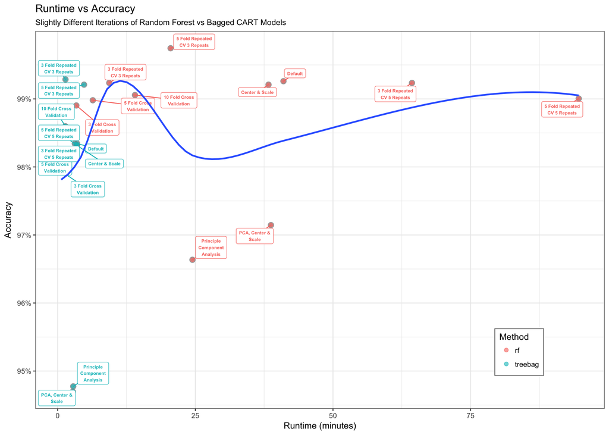

```r
ggplot(rt, aes(Runtime, Accuracy)) +
     geom_point(size = 3, color = "gray50", alpha = 0.6) +
     geom_point(size = 2, alpha = 0.6, aes(color = Method)) +
     geom_label_repel(size = 2, fontface = "bold", min.segment.length = 0.1, show.legend = FALSE,
                      aes(label = str_wrap(Type, 15), color = Method)) +
     geom_smooth(se = FALSE, method = loess) +
     scale_y_continuous(labels = percent) +
     labs(x = "Runtime (minutes)", y = "Accuracy",
          title = "Runtime vs Accuracy",
          subtitle = "Slightly Different Iterations of Random Forest vs Bagged CART Models") +
     theme_bw() +
     theme(legend.position = c(0.85,0.15), legend.background = element_rect(color = "gray50"))
```

Somewhat surprisingly, there is not a strong correlation between runtime and accuracy.

The plot above shows that most of the models achieved accuracy of 98% and above, while the random forest models generally took longer to run.

Notice also that principle component analysis seemed to diminish the accuracy of the model whenever it was included. Perhaps there is some subtlety in the correlated predictors which is important for making predictions.

Repeated cross validation, ‘repeatedcv’ seemed to generally perform better than non-repeated, ‘cv’. Somewhat surprisingly, increasing the number of repeats or folds did not necessarily improve accuracy.

The next plot below is the same as the one above but faceted by the way each model was trained. In every case the random forest model took longer to run. In all cases but one, the random forest model slightly outperformed the bagged CART model.

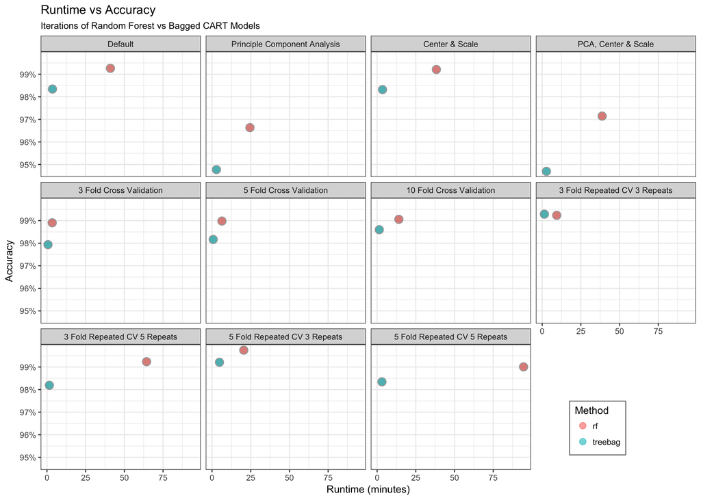

```r
ggplot(rt, aes(Runtime, Accuracy)) +
     geom_point(size = 4, color = "gray50", alpha = 0.6) +
     geom_point(size = 3, alpha = 0.6, aes(color = Method)) +
     scale_y_continuous(labels = percent) +
     labs(x = "Runtime (minutes)", y = "Accuracy",
          title = "Runtime vs Accuracy",
          subtitle = "Iterations of Random Forest vs Bagged CART Models") +
     theme_bw() +
     theme(legend.position = c(0.85,0.1), legend.background = element_rect(color = "gray50")) +
     facet_wrap(~Type)
```

The next plot shows the accuracy of each model. It’s interesting that the default values ‘train(classe ~ ., method = “rf”, data = training)’ for the random forest model outperformed all but one of the different variations.

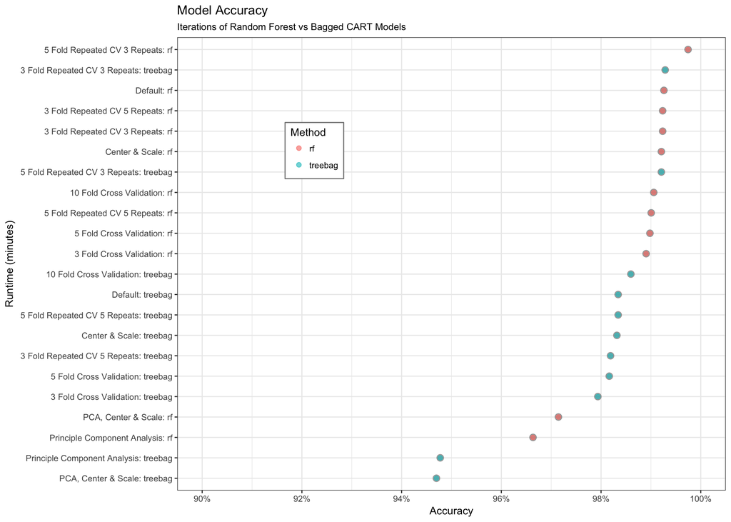

```r
rt %>%
     mutate(Lab = paste(Type, Method, sep = ": ")) %>%
     ggplot(aes(reorder(Lab, Accuracy), Accuracy)) +
     geom_point(size = 3, color = "gray50", alpha = 0.6) +
     geom_point(size = 2, alpha = 0.6, aes(color = Method)) +
     labs(x = "Runtime (minutes)", y = "Accuracy",
          title = "Model Accuracy",
          subtitle = "Iterations of Random Forest vs Bagged CART Models") +
     scale_y_continuous(labels = percent, limits = c(0.9,1), breaks = seq(0.9,1,0.02)) +
     coord_flip() +
     theme_bw() +
     theme(legend.position = c(0.25,0.75), legend.background = element_rect(color = "gray50"))
```

# Blend best models

```r
blend <- data.frame(rfPredict,bagPredict_cv10,bagPredict_rcv3_3,rfPredict_rcv5_3,
                    rfPredict_rcv3_3, classe = testing$classe); str(blend)
```

```
## 'data.frame':    3923 obs. of  6 variables:
##  $ rfPredict        : Factor w/ 5 levels "A","B","C","D",..: 1 1 1 1 1 1 1 1 1 1 ...
##  $ bagPredict_cv10  : Factor w/ 5 levels "A","B","C","D",..: 1 1 1 1 1 1 1 1 1 1 ...
##  $ bagPredict_rcv3_3: Factor w/ 5 levels "A","B","C","D",..: 1 1 1 1 1 1 1 1 1 1 ...
##  $ rfPredict_rcv5_3 : Factor w/ 5 levels "A","B","C","D",..: 1 1 1 1 1 1 1 1 1 1 ...
##  $ rfPredict_rcv3_3 : Factor w/ 5 levels "A","B","C","D",..: 1 1 1 1 1 1 1 1 1 1 ...
##  $ classe           : Factor w/ 5 levels "A","B","C","D",..: 1 1 1 1 1 1 1 1 1 1 ...
```

```r
head(blend, 10)
```

```
##    rfPredict bagPredict_cv10 bagPredict_rcv3_3 rfPredict_rcv5_3
## 1          A               A                 A                A
## 2          A               A                 A                A
## 3          A               A                 A                A
## 4          A               A                 A                A
## 5          A               A                 A                A
## 6          A               A                 A                A
## 7          A               A                 A                A
## 8          A               A                 A                A
## 9          A               A                 A                A
## 10         A               A                 A                A
##    rfPredict_rcv3_3 classe
## 1                 A      A
## 2                 A      A
## 3                 A      A
## 4                 A      A
## 5                 A      A
## 6                 A      A
## 7                 A      A
## 8                 A      A
## 9                 A      A
## 10                A      A
```

The following plot is to get a sense of the hits vs misses in each models predictions.

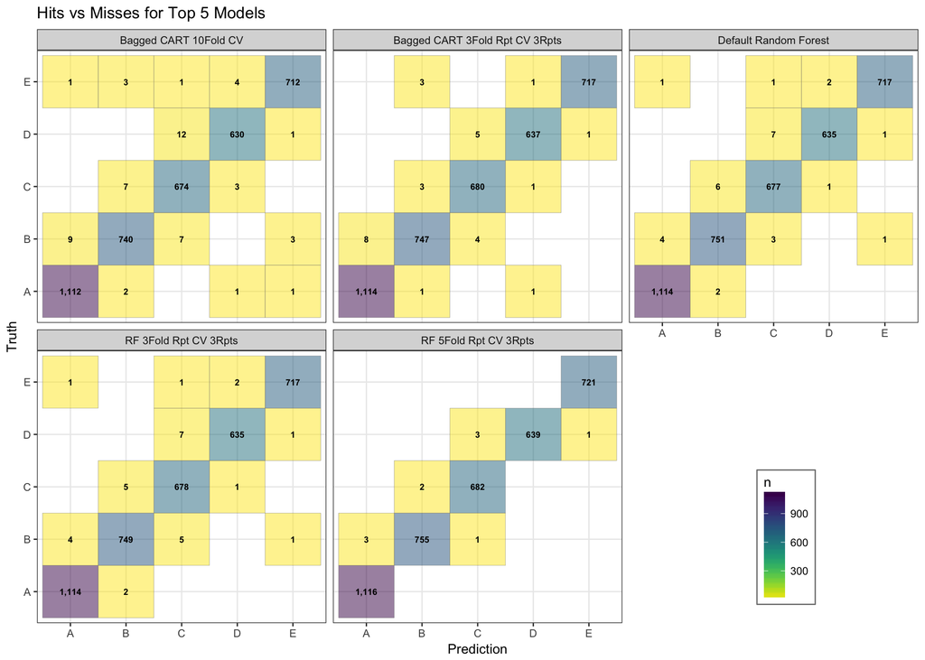

```r
blend %>%
     rename(Default_Random_Forest = rfPredict,
            Bagged_CART_3Fold_Rpt_CV_3Rpts = bagPredict_rcv3_3,
            RF_5Fold_Rpt_CV_3Rpts = rfPredict_rcv5_3,
            RF_3Fold_Rpt_CV_3Rpts = rfPredict_rcv3_3,
            Bagged_CART_10Fold_CV = bagPredict_cv10) %>%
     gather(Measure, Var, -classe) %>%
     transform(Measure = gsub("_", " ", Measure)) %>%
     group_by(Measure,Var,classe) %>%
     tally() %>% ungroup() %>% arrange(desc(n)) %>%
     ggplot(aes(Var,classe)) +
     geom_tile(color = "gray50", alpha = 0.5, aes(fill = n)) +
     geom_text(size = 2.5, fontface = "bold", aes(label = comma(n))) +
     labs(x = "Prediction", y = "Truth",
          title = "Hits vs Misses for Top 5 Models") +
     scale_fill_viridis(direction = -1) +
     facet_wrap(~Measure) +
     theme_bw() +
     theme(legend.position = c(0.85,0.15), legend.background = element_rect(color = "gray50"))
```

Fit a new random forest model that relates the outcome, ‘classe’, to the different predictions from each model

```r
# set.seed(7511)
# x1 <- Sys.time()
# blendMod <- train(classe ~.,
#              method = "rf",
#              data = blend)
# x2 <- Sys.time()
# x2 - x1 # Time difference of 2.640546 mins
# saveRDS(blendMod, paste(dir, "blendMod.rds", sep = ""))

blendMod <- readRDS(paste(dir, "blendMod.rds", sep = ""))
```

Create predictions for the holdout validation set

```r
rfPredict <- predict(rfMod, validation)
bagPredict_cv10 <- predict(bagMod_cv10, validation)
bagPredict_rcv3_3 <- predict(bagMod_rcv3_3, validation)
rfPredict_rcv5_3 <- predict(rfMod_rcv3_3, validation)
rfPredict_rcv3_3 <- predict(rfMod_rcv5_3, validation)
```

Build a data frame with validation set predictions

```r
pred_df_valid <- data.frame(rfPredict,bagPredict_cv10,bagPredict_rcv3_3,rfPredict_rcv5_3,rfPredict_rcv3_3)
```

Predict ‘classe’ using the combined model on the predictions of the validation set

```r
combPredV <- predict(blendMod, pred_df_valid)
```

Evaluate

```r
cm_blendV <- confusionMatrix(combPredV, validation$classe); cm_blendV$overall['Accuracy']
```

```
##  Accuracy
## 0.9926077
```

## Out of Sample Error

Confusion matrix for the blended model predictions on the validation set…

```r
cm_blendV
```

```
## Confusion Matrix and Statistics
##
##           Reference
## Prediction    A    B    C    D    E
##          A 1113    3    0    0    0
##          B    2  753    5    0    2
##          C    1    1  677    7    2
##          D    0    1    2  636    2
##          E    0    1    0    0  715
##
## Overall Statistics
##
##                Accuracy : 0.9926
##                  95% CI : (0.9894, 0.995)
##     No Information Rate : 0.2845
##     P-Value [Acc > NIR] : < 2.2e-16
##
##                   Kappa : 0.9906
##  Mcnemar's Test P-Value : NA
##
## Statistics by Class:
##
##                      Class: A Class: B Class: C Class: D Class: E
## Sensitivity            0.9973   0.9921   0.9898   0.9891   0.9917
## Specificity            0.9989   0.9972   0.9966   0.9985   0.9997
## Pos Pred Value         0.9973   0.9882   0.9840   0.9922   0.9986
## Neg Pred Value         0.9989   0.9981   0.9978   0.9979   0.9981
## Prevalence             0.2845   0.1935   0.1744   0.1639   0.1838
## Detection Rate         0.2837   0.1919   0.1726   0.1621   0.1823
## Detection Prevalence   0.2845   0.1942   0.1754   0.1634   0.1825
## Balanced Accuracy      0.9981   0.9946   0.9932   0.9938   0.9957
```

**Estimate the out-of-sample error rate**

```r
1 - cm_blendV$overall['Accuracy']
```

```
##    Accuracy
## 0.007392302
```

The estimated out-of-sample error rate is less than one percent.

With > 99% accuracy, we should expect to correctly classify at least 19 of the 20 test questions

# Create prediction for the 20 test questions

```r
rfPredict <- predict(rfMod, tst)
bagPredict_cv10 <- predict(bagMod_cv10, tst)
bagPredict_rcv3_3 <- predict(bagMod_rcv3_3, tst)
rfPredict_rcv5_3 <- predict(rfMod_rcv3_3, tst)
rfPredict_rcv3_3 <- predict(rfMod_rcv5_3, tst)
```

Create a data frame with test predictions

```r
pred_df_tst <- data.frame(rfPredict,bagPredict_cv10,bagPredict_rcv3_3,rfPredict_rcv5_3,rfPredict_rcv3_3)
```

Fit the blended model to the predictions

```r
combPred_tst <- predict(blendMod, pred_df_tst);combPred_tst
```

```
##  [1] B A B A A E D B A A B C B A E E A B B B
## Levels: A B C D E
```